# First Steps in Python

```python
%load_ext pretty_jupyter
```

## First Steps in Python and Learning Outcomes

This walkthrough is part of the [ECLR](https://datasquad.github.io/ECLR/) page.

Here we assume that you have installed Python on your computer (see the [Python Installation](https://datasquad.github.io/ECLR/Py_coding/Py_Install.html) walkthrough).

In this walkthrough, we’ll start with the basics of programming and in particular the basics of a good workflow. From there, we’ll discuss how to manage data, perform calculations. By the end of this section, you’ll have the foundation to explore advanced topics and unlock Python’s full potential—whether in data science, econometrics, or creating the next big app or website.

This document allows you to experience fundamental functionality using Python and Jupyter Notebook. In particular, this is for you:

- write your first Python code!
- to explore basic syntax by understanding Python's fundamental data types: integers, floats, strings, and booleans and using the built-in Python functions like `print()` to display outputs and `type()` to inspect data types.
- to learn how to import libraries such as `numpy` and `pandas` to start working with arrays and tabular data and install additional libraries directly from Jupyter Notebook using `!pip install`.
- to recognise and fix common Python errors, such as `SyntaxError` and `NameError`.
- to learn about about data types
- to undertake some basic data manipulation
- to develop a roadmap to explore advanced Python topics such as implementing visualisation techniques with `matplotlib` and `seaborn` and advanced econometric modelling with `statsmodels` or `scikit-learn`.

We recommend that you have installed VS Code as your IDE.

## Prepare your Workspace

Before you start, you should create a space (i.e. a folder) on your computer from where you are planning to store all your Python files and data. Ensure you know this folder's exact location and its full path. This will help you navigate to it easily from within Jupyter Notebook.

For instance, if you create a folder named `PyWork` on your **C drive**, then the path to your folder will be `C:/PyWork`.

For this computer lab, we are using the datafile STATS19_GM_AccData.csv. You should download this data file (click on the download icon from that linked page) into the folder you just created and want to work from. The data file in your working folder ensures that Python can easily access it without complex file paths. It is also a good idea to have the [Data Dictionary](https://assets.publishing.service.gov.uk/government/uploads/system/uploads/attachment_data/file/995422/stats19.pdf) ready. This will help you understand the structure and variables in the data.

## Prepare your script file or notebook and libraries

A crucial part of working with Python is that you document your work by saving all the code commands you apply in either a script file (`.py`) or a Jupyter notebook (`.ipynb`).

We recommend that on most occasions (and certainly at the beginning of your coding career) you should work in **Jupyter Notebook** with the extension `.ipynb`. This file allows you to save your commands (code), comments, and outputs in one document. The process that you need to follow consists of the steps outlined here:

- Open VS Code.
- Create a new notebook by going to **File** → **New File** and then chose Jupyter Notebook.
- Give that file a sensible name and save it in your working directory (e.g., `my_first_pywork.ipynb`).
- Remember to frequently save your work (**CTRL + S** on windows or **Cmd+S** on a Mac).

Now, let's create a Jupyter Notebook file following the abovementioned steps. A Jupyter notebook basically consists of `code` and `markdown` blocks. `markdown` blocks, like the one in the image below, basically contain text and `code` blocks (see below) will contain python code. It is best to start with a markdown block in which you tell yourself what this notebook is about. Whether a block is `code` or `markdown` you can see at the bottom right of every block. You can change between the two types if you click the three dots in the top right of each block.

If you want a new block you click on either the `+ Code` or the `+ Markdown` button. A list with useful Jupyter notebook formatting support is available from [here](https://www.ibm.com/docs/en/watson-studio-local/1.2.3?topic=notebooks-markdown-jupyter-cheatsheet).

[figure not shown]

Let's add a code block in which we check (or set) the working directory Unlike R, Python **does not have** a `setwd()` function. Instead, you can use the `os` module to check and change your working directory. Setting the working directory ensures that Python knows where to look for files and where to save outputs!

```python
import os  # Import the os library
print("Current Working Directory:", os.getcwd())
```

```
Current Working Directory: c:\Pycode\ECLR\Py_coding
```

> Note: Adding comments to your Python code is essential to avoid staring at it tomorrow, wondering, “What was I even thinking here?” In Python, the computer ignores anything after the # symbol but is treasured by you (or anyone else reading your code). Comments are not for Python; they’re for your sanity!

In your VS Code window this will look as in the image below. If you have a code chunk you can execute the code in the chunk you either click the play button (yellow highlight) or you type **CTRL + ENTER**. The output of the code will show directly below (green highlight).

[figure not shown]

From now onwards we will not show screenshots of a Jupyter notebook anylonger, but only discuss the code which you will copy and paste into a code chunk in your notebook. By the way, this very document has been written as a Jupyter notebook.

If you want to **change the working directory**, you will have to use the `os.chdir()` function and in the parentheses `()` specify the full path of your desired folder. The `os.chdir()` function changes the current working directory to the specified folder. Note that all backward slashes (`\`) have to be replaced by forward slashes (`/`) to avoid escape character issues.

```
os.chdir("C:/PythonWork")  # Replace with your desired path
print("New Working Directory:", os.getcwd())
```

### Python libraries

Python libraries provide additional functions that extend Python’s capabilities. You will have to use libraries as lots of the great functionality that gives Python its power comes through libraries. Libraries have to be loaded (or `import`ed in python speak) before every use (typically at the beginning of each script or notebook). However, before you can `import` them you will have to install them. Installing you only have to do once on your computer.

We start by attempting to load a library that, most likely is not available to you at this stage. It is called `pybrain`. We only use this here for you to see what would happen if you were trying to load/import a library that has not been installed yet. If you run the following code you should get an error message.

```
import pybrain as pybrain
```

Your likely error message will look something like this:

> ModuleNotFoundError Traceback (most recent call last)  
> ~\AppData\Local\Temp\ipykernel_7984\1738476634.py in  
> -> 1 import pybrain as pybrain  
> ModuleNotFoundError: No module named 'pybrain'

Essentially python is telling you that the `pybrain` library is not yet installed on your computer. On this occasion it is fairly straightforward to understand the error message. Unfortunately that is not always the case.

#### Installing libraries

This needs doing once on your computer. This is done via the terminal. The terminal is a tool via which you can type instructions to your computer (as opposed to Python). And the installing is done by your computer and not by Python. Let's say we need to install the packages `pandas` and `numpy` as we need them later.

Open the terminal by clicking on the **Terminal item** in the menu and chosing **New Terminal**. This will open at the bottom of your screen as indicated in this screenshot.

[figure not shown]

In the terminal you type `pip install` and then the name of the package you wish to install, here `pandas`. Then press enter and the computer will do its stuff. When you see the prompt again (here `C:\Pycode\ECLR`) and there is no error message you are good to go. Repeat that for all the packages needed.

We typically do this via the terminal as we do this only once on the computer and there is no need to save that code and re-use it.

#### Loading/Importing libraries

Let's load the libraries that we want to use, assuming that they have been installed. Make sure you execute/run the code. We will explain what is happening below.

```python
# Import necessary libraries

import os as os            # for operations at the operating system level
import pandas as pd        # For data manipulation
import numpy as np         # For numerical computations
```

The command `import pandas as pd` imported all the functions that are associated with the `pandas` library. If we want to access functionality from that package, for instance the `DataFrame` function which will create a dataframe, we can, from now on, call this using the `pd` prefix, i.e. we would call it using `pd.DataFrame()`.

The same has happened with the `numpy` llibrary which is used for many mathematical and statistical computations. The function which calculates the mean will be called, for instance, as `np.mean()`.

## Data Upload

Ensure that your working directory is set to the directory you are working from.

```python
os.chdir("C:/Pycode")  # Replace with your desired path
print("New Working Directory:", os.getcwd())
```

```
New Working Directory: C:\Pycode
```

```python
import pandas as pd

# Correct method to read the CSV file
file_name = "STATS19_GM_AccData.csv"
accdata = pd.read_csv(file_name)  # Use read_csv, not read.csv
```

If you get an error message `FileNotFoundError: [Errno 2] No such file or directory: 'STATS19_GM_AccData.csv'` this means that the file is not in your working directory. Check that it is in the folder and that you spelled its name correctly.

The data now has been successfully loaded. It is stored in a panda data frame. You could think about it like a spreadsheet with rows and columns. It is time to inspect its structure using the following line:

```python
# View basic information about the dataset
accdata.info()
```

```
<class 'pandas.core.frame.DataFrame'>
RangeIndex: 42624 entries, 0 to 42623
Data columns (total 27 columns):
 #   Column                         Non-Null Count  Dtype
---  ------                         --------------  -----
 0   Accident Index                 42624 non-null  int64
 1   Year                           42624 non-null  int64
 2   Severity                       42624 non-null  int64
 3   NumberVehicles                 42624 non-null  int64
 4   NumberCasualties               42624 non-null  int64
 5   OutputDate                     42624 non-null  object
 6   Day                            42624 non-null  int64
 7   OutputTime                     42624 non-null  object
 8   Easting                        42624 non-null  int64
 9   Northing                       42624 non-null  int64
 10  LocalAuthority                 42624 non-null  int64
 11  Road1Class                     42624 non-null  int64
 12  Road1Number                    42624 non-null  int64
 13  CarriagewayType                42624 non-null  int64
 14  SpeedLimit                     42624 non-null  int64
 15  JunctionDetail                 42624 non-null  int64
 16  JunctionControl                42624 non-null  int64
 17  Road2Class                     42624 non-null  int64
 18  Road2Number                    42624 non-null  int64
 19  PedCrossingHumanControl        42624 non-null  int64
 20  PedCrossingPhysicalFacilities  42624 non-null  int64
 21  LightingCondition              42624 non-null  int64
 22  WeatherCondition               42624 non-null  int64
 23  RoadSurface                    42624 non-null  int64
 24  SpecialConditions              42624 non-null  int64
 25  CarriagewayHazard              42624 non-null  int64
 26  PlaceReported                  42624 non-null  int64
dtypes: int64(25), object(2)
memory usage: 8.8+ MB
```

The `info()` method is `pandas` concisely summarises the `DataFrame`. The `output` indicates 42,624 (rows), counting from 0 to 42,623). Each row represents one observation, such as a recorded road accident in Greater Manchester between 2010 and 2020. Each accident has variables which characterise the accident. In the table provided:

- the `Non-Null Count` column shows the number of non-missing (valid) entries for each column. This example shows that the **Non-Null Count equals 42,624** for all columns listed, meaning there are no missing values in these variables! If any column had missing values, this count would be less than `42624`.
- the `Dtype` column specifies each variable's **data type**. More specifically, we mostly have `int64`, which represents a numerical value with integer values ( e.g., `Year`, `Severity`). We can also indicate `object` usually representing text or categorical data.

These are some important variables to focus on:

- `Accident.Index`: Unique identifier for each accident.
- `Year`: Year in which the accident occurred.
- `Severity`: Severity of the accident.
- `NumberVehicles`: Number of vehicles involved.
- `NumberCasualties`: Number of casualties involved.
- `LightingCondition`: Lighting conditions at the time of the accident.
- `WeatherCondition`: Weather conditions at the time of the accident.
- `Road1Class`: Classification of the main road (lower numbers = more major roads).
- `RoadSurface`: Road surface condition at the time of the accident.

We can also look at the first few rows of our dataset using the `head()` function. We can specify the number of rows to display e.g., `accdata.head(5)` for the first 5 rows, as follows:

```python
print (accdata.head(5))
```

```
   Accident Index  Year  Severity  NumberVehicles  NumberCasualties  \
0    102262412010  2010         3               2                 1
1    102262562010  2010         3               2                 1
2    102264322010  2010         3               2                 1
3    107264182010  2010         3               3                 1
4    114261842010  2010         3               1                 1

   OutputDate  Day OutputTime  Easting  Northing  ...  Road2Class  \
0  01/01/2010    6      13:10   382347    390025  ...           3
1  01/01/2010    6      11:10   381892    390582  ...           7
2  01/01/2010    6      17:30   385840    403134  ...           7
3  01/01/2010    6      13:49   377762    403302  ...           1
4  01/01/2010    6      01:55   355982    404620  ...           0

   Road2Number  PedCrossingHumanControl  PedCrossingPhysicalFacilities  \
0         5103                        0                              0
1            0                        0                              0
2            0                        0                              0
3           60                        0                              0
4            0                        0                              0

   LightingCondition  WeatherCondition  RoadSurface  SpecialConditions  \
0                  1                 1            4                  0
1                  1                 1            4                  0
2                  4                 1            2                  0
3                  3                 9            1                  0
4                  7                 9            1                  0

   CarriagewayHazard  PlaceReported
0                  0              1
1                  0              1
2                  0              2
3                  0              2
4                  0              2

[5 rows x 27 columns]
```

### Data viewing

Above you already saw the use of the `.head()` method to see some data. But often you will want to have a look at the whole dataset (basically the spreadsheet). This is easily done in VS Code. Once you created any objects (we already created `acc_data` and `file_name`) you should see at the top of your notebook window a **Jupyter Variables** button. Click that and at the bottom of your screen you will see a list of the objects that have been created.

[figure not shown]

This view alone is already useful as it can be important to check whether objects have been created. If you double click on `accdata` you should either see the window below, or you will get a popup message telling you that you need to install a Data Viewer extension for VS Code. Say **OK** and you will get suggestions. We recommend the **Data Wrangler** extension. Install and then enable it. Once you have done that, double clicking on `acc_data` should create a new window in VS Code that displays the spreadsheet with a graphical data representation (histograms) at the top.

[figure not shown]

The ability of seeing a list of your objects and actually seeing the data is one of the most compelling reasons to use an IDE.

### Saving and re-starting

Congratulations! You’ve written your first Python code in a Jupyter Notebook. Now, it’s time to take a well-deserved break. Save your notebook by typing **CTRL + S** (in Windows) or **CMD + S** (on a Mac) or by chosing the **Save** option in the **File** menu drop down box. After that, close VS Code, pretend it is the end of your working day. You don’t need to do this every time, but let’s do it now to demonstrate the value of scripts or notebooks. When you’re ready, reopen VS Code and navigate to your saved notebook file (the one with the .ipynb extension). Open it, and you’ll see that all your code is still there, just as you left it. However, the variables and data that were stored in memory will no longer be available.

Here’s where the magic of notebooks shines: click on **Run All**, or run your cells sequentially by pressing **CTRL + Enter** in each cell. All the commands in your notebook will re-execute, and your data (`accdata`, in this case) will be available again and ready for further analysis. So after pressing one button you are back at where you finished "yesterday". So you again started out from the original dataset.

Once you understand the usefulness of this workflow, the following very important principle will make sense.

> An essential principle when working with data in Python is **never to modify your original data file**, which in this case is the `STATS19_GM_AccData.csv` file. This ensures the integrity of your data and allows you to start fresh whenever needed. Any changes made directly to the CSV file are permanent and cannot be undone. Therefore, keeping the original file untouched ensures that you always have a reliable reference point for your analysis.

## Accessing Data

The `accdata` object in Python represents the dataset as a `DataFrame`, which is essentially a table-like structure. You can view the entire dataset or specific subsets of it using indexing and slicing techniques.

In Jupyter Notebook, to view the entire dataset you can look at it via the variable list (just as above) or you can run:

```python
accdata
```

|  | Accident Index | Year | Severity | NumberVehicles | NumberCasualties | OutputDate | Day | OutputTime | Easting | Northing | ... | Road2Class | Road2Number | PedCrossingHumanControl | PedCrossingPhysicalFacilities | LightingCondition | WeatherCondition | RoadSurface | SpecialConditions | CarriagewayHazard | PlaceReported |
| --- | --- | --- | --- | --- | --- | --- | --- | --- | --- | --- | --- | --- | --- | --- | --- | --- | --- | --- | --- | --- | --- |
| 0 | 102262412010 | 2010 | 3 | 2 | 1 | 01/01/2010 | 6 | 13:10 | 382347 | 390025 | ... | 3 | 5103 | 0 | 0 | 1 | 1 | 4 | 0 | 0 | 1 |
| 1 | 102262562010 | 2010 | 3 | 2 | 1 | 01/01/2010 | 6 | 11:10 | 381892 | 390582 | ... | 7 | 0 | 0 | 0 | 1 | 1 | 4 | 0 | 0 | 1 |
| 2 | 102264322010 | 2010 | 3 | 2 | 1 | 01/01/2010 | 6 | 17:30 | 385840 | 403134 | ... | 7 | 0 | 0 | 0 | 4 | 1 | 2 | 0 | 0 | 2 |
| 3 | 107264182010 | 2010 | 3 | 3 | 1 | 01/01/2010 | 6 | 13:49 | 377762 | 403302 | ... | 1 | 60 | 0 | 0 | 3 | 9 | 1 | 0 | 0 | 2 |
| 4 | 114261842010 | 2010 | 3 | 1 | 1 | 01/01/2010 | 6 | 01:55 | 355982 | 404620 | ... | 0 | 0 | 0 | 0 | 7 | 9 | 1 | 0 | 0 | 2 |
| ... | ... | ... | ... | ... | ... | ... | ... | ... | ... | ... | ... | ... | ... | ... | ... | ... | ... | ... | ... | ... | ... |
| 42619 | 100792182020 | 2020 | 3 | 2 | 1 | 31/12/2020 | 5 | 06:40 | 369900 | 406661 | ... | 0 | 0 | 0 | 0 | 4 | 3 | 3 | 0 | 0 | 2 |
| 42620 | 102787772020 | 2020 | 3 | 2 | 1 | 31/12/2020 | 5 | 06:30 | 384711 | 392657 | ... | 0 | 0 | 0 | 0 | 7 | 3 | 3 | 0 | 0 | 2 |
| 42621 | 102790472020 | 2020 | 3 | 2 | 2 | 31/12/2020 | 5 | 20:10 | 387961 | 397434 | ... | 7 | 0 | 0 | 5 | 4 | 1 | 4 | 0 | 0 | 1 |
| 42622 | 106790322020 | 2020 | 3 | 2 | 2 | 31/12/2020 | 5 | 15:00 | 390392 | 412917 | ... | 4 | 640 | 0 | 0 | 1 | 1 | 2 | 0 | 0 | 2 |
| 42623 | 110787712020 | 2020 | 2 | 1 | 1 | 31/12/2020 | 5 | 11:56 | 394153 | 399197 | ... | 7 | 0 | 0 | 0 | 1 | 1 | 1 | 0 | 0 | 1 |

42624 rows × 27 columns

Let's say we want to explore various ways to subset the `accdata` DataFrame. To subset in coding lingo means to access particular parts of the dataframe. To select specific rows we can run the following code:

```python
# Select the first row
print(accdata.iloc[0])  # Note: Python indexing starts at 0, not 1

# Select rows 7 to 10 (inclusive of start, exclusive of end)
print(accdata.iloc[7:11])
```

```
Accident Index                   102262412010
Year                                     2010
Severity                                    3
NumberVehicles                              2
NumberCasualties                            1
OutputDate                         01/01/2010
Day                                         6
OutputTime                              13:10
Easting                                382347
Northing                               390025
LocalAuthority                            102
Road1Class                                  5
Road1Number                              5166
CarriagewayType                             3
SpeedLimit                                 50
JunctionDetail                              6
JunctionControl                             2
Road2Class                                  3
Road2Number                              5103
PedCrossingHumanControl                     0
PedCrossingPhysicalFacilities               0
LightingCondition                           1
WeatherCondition                            1
RoadSurface                                 4
SpecialConditions                           0
CarriagewayHazard                           0
PlaceReported                               1
Name: 0, dtype: object
    Accident Index  Year  Severity  NumberVehicles  NumberCasualties  \
7     101262292010  2010         3               2                 1
8     102256832010  2010         3               2                 1
9     102256922010  2010         3               1                 1
10    102262112010  2010         2               2                 2

    OutputDate  Day OutputTime  Easting  Northing  ...  Road2Class  \
7   02/01/2010    7      13:00   381775    410735  ...           7
8   02/01/2010    7      18:25   383868    394065  ...           4
9   02/01/2010    7      18:35   384681    395127  ...           7
10  02/01/2010    7      06:50   384660    397391  ...           0

    Road2Number  PedCrossingHumanControl  PedCrossingPhysicalFacilities  \
7             0                        0                              0
8          6010                        0                              5
9             0                        0                              0
10            0                        0                              0

    LightingCondition  WeatherCondition  RoadSurface  SpecialConditions  \
7                   1                 3            3                  0
8                   4                 3            2                  0
9                   4                 8            4                  0
10                  4                 1            4                  0

    CarriagewayHazard  PlaceReported
7                   0              2
8                   0              1
9                   0              1
10                  0              1

[4 rows x 27 columns]
```

The `iloc` stands for "integer location" and the `iloc[0]` accesses the first row of the `DatFrame` using positional indexing.

> Note that in Python, indexing starts at 0, unlike R, which starts at 1.

We can follow the same proccedure for selecting specific columns instead of rows by using the `iloc[:, 1]`and for selecting a range of columns `iloc[:, 3:6]`.

Let's say now that we want to **select particular variables** (columns in a spreadsheet). We can do this by running this line of code:

```python
accdata['SpeedLimit']
```

```
0        50
1        30
2        30
3        30
4        30
         ..
42619    30
42620    30
42621    30
42622    30
42623    30
Name: SpeedLimit, Length: 42624, dtype: int64
```

`accdata['SpeedLimit']` acceesses the `SpeedLimit` column by it's name. This results in a **pandas Series** which is a one-dimensional array-like structure. If you wish to access two variables you could do that as follows:

```python
sel_col = ['SpeedLimit', 'Road1Class']
accdata[sel_col]
```

|  | SpeedLimit | Road1Class |
| --- | --- | --- |
| 0 | 50 | 5 |
| 1 | 30 | 7 |
| 2 | 30 | 4 |
| 3 | 30 | 4 |
| 4 | 30 | 4 |
| ... | ... | ... |
| 42619 | 30 | 6 |
| 42620 | 30 | 5 |
| 42621 | 30 | 4 |
| 42622 | 30 | 7 |
| 42623 | 30 | 7 |

42624 rows × 2 columns

In `sel_col` we have created a list of items, here the two variable names, which was then used in `accdata[sel_col]`.

Lists are an incredibly important object type in Python. YOu could create a list containing **mixed data types**? We can do this as follows:

```python
silly_list = ["Countries in the EU", 28 - 1, ":-("]
```

Creating a list of different data types could be quite useful when creating dynamic datasets or labels. In this particular example, we have created a list that combines two strings ( e.g., `"Countries in the EU"` and `":-("` ) and an integer resulting from the subtraction operation (e.g., `28-1`).

## Investigate Data 1

Let’s explore how the severity of an accident is coded in the dataset. In Python, this can be done using the `unique()` method from `pandas` and the `value_counts()` method to inspect the distribution of values.

```python
# Find unique values in the 'Severity' column
unique_severity = accdata['Severity'].unique()
print("Unique values in 'Severity':", unique_severity)
```

```
Unique values in 'Severity': [3 2 1]
```

The output indicates that the `Severity` variable takes three distinct values: 1, 2, and 3. But what do the values 1, 2 or 3 represent? You could go to the data dictionary and check the coding, although on this occasion that turns out less than conclusive. Does a `1` in the Severity variable represent a fatal accident or a slight one? To determine this, we can analyse the data directly. It’s reasonable to assume that slight accidents occur more frequently than fatal ones. While the data dictionary may provide this information, we can infer the meaning of each category by looking at the distribution of accidents across these values. Categories with more observations are likely less severe (e.g., slight accidents), while those with fewer observations are likely more severe.

The easiest way to look at this is to use the `value_counts()` method on the `Severity` variable.

```python
# Count the number of accidents in each severity category
severity_counts = accdata['Severity'].value_counts()
print("Counts of each Severity level:\n", severity_counts)
```

```
Counts of each Severity level:
 3    35523
2     6519
1      582
Name: Severity, dtype: int64
```

This function counts the occurrences of each unique value in the column and sorts them in descending order. So, from the output provided here, we can conclude that category 1 represents the most severe accident category and category 3 represents the least severe (e.g., slight accidents) one.

## Data Formats

From the dataset overview (`accdata.info()`), we can see:

1. Most variables, including `Severity`, `WeatherCondition`, and `RoadSurface`, are stored as `int64`, meaning they are treated as numeric values.
2. Text-based variables like `OutputDate` and `OutputTime` are stored as object, which is how Python handles strings.

While these numeric variables (`Severity`, `WeatherCondition`, etc.) are numbers, they actually represent categories. For instance, `Severity`: 1 = Fatal, 2 = Serious, 3 = Slight. It’s more meaningful to treat these variables as categorical instead of numeric. To do this in Python, we use `pandas`' `astype('category')` to convert a numeric column to a categorical column. Additionally, we can assign readable labels using `cat.rename_categories` method.

Hence we will create a new variables, `Severityf` which contains the same info, but just in a way easier to understand.

```python
# Convert 'Severity' to a categorical variable
accdata['Severityf'] = accdata['Severity'].astype('category')
accdata['Severityf'] = accdata['Severityf'].cat.rename_categories({1: "Fatal", 2: "Serious", 3: "Slight"})

# Check the result
print(accdata['Severityf'].value_counts())
```

```
Slight     35523
Serious     6519
Fatal        582
Name: Severityf, dtype: int64
```

Of course you should look at this and say "How on earth should I have known how to do that?".

#### How to find the code?

##### Use the community

The point is that you are not expected to know all details. When we wrote this we also had to check this. Here are two techniques of how to find solutions to your coding questions.

##### Search the internet

YOu could go to your favourite internet search engine and enter search terms as the following: "python pandas rename category". Everyone will get a slightly different list of links, but you are likely to quickly find either links to stackoverflow.com (which is a good place to go) or to documentation for python functions. The stackoverflow link we got gave, amongst others, the following example.

[figure not shown]

If you compare the code here with the one we used above you can see that we merely adjusted the code we found here. Adapting such a solution to your problem is a very common activity as a coder.

##### Ask a GenAI engine

GenAI engines such as ChatGPT or Claude can help you out with coding problems. You need to start with a clear problem setup in order to get something useful.

[figure not shown]

This image only shows the first method proposed by ChatGPT and you can see it is different. However, it made multiple proposals and the method we used above also appears a little further down.

Now create two new variables `WeatherConditionf` and `RoadSurfacef` which achieve the same for the `WeatherCondition` and `RoadSurface` variables. Converting `WeatherCondition` to a categorical variable involves you checking the [Data Dictionary](https://assets.publishing.service.gov.uk/government/uploads/system/uploads/attachment_data/file/995422/stats19.pdf) for the right ordering. Then you should run the following code:

```python
# Convert 'WeatherCondition' to a categorical variable
accdata['WeatherConditionf'] = accdata['WeatherCondition'].astype('category')
accdata['WeatherConditionf'] = accdata['WeatherConditionf'].cat.rename_categories({
    1: 'Fine, no winds',
    2: 'Raining, no winds',
    3: 'Snow, no winds',
    4: 'Fine, with winds',
    5: 'Raining, with winds',
    6: 'Snow, with winds',
    7: 'Fog or mist',
    8: 'Other',
    9: 'Unknown'
})

# Check the result
print(accdata['WeatherConditionf'].value_counts())
```

```
Fine, no winds         32535
Raining, no winds       5997
Unknown                 1717
Other                    859
Raining, with winds      705
Fine, with winds         404
Snow, no winds           246
Fog or mist               96
Snow, with winds          65
Name: WeatherConditionf, dtype: int64
```

Again, here the `.astype('category')` method creates the categorical variable. The `cat.rename_categories()` method maps each numeric category to its descriptive label (e.g., 1 -> 'Fine, no winds'). Finally, the `value_counts()` function verifies the transfomation and ensures the correct mapping.

Converting `RoadSurface` to a categorical variable involves you again checking the [Data Dictionary](https://assets.publishing.service.gov.uk/government/uploads/system/uploads/attachment_data/file/995422/stats19.pdf) for the correct ordering. Then you should run the following code:

```python
# Convert 'RoadSurface' to a categorical variable
accdata['RoadSurfacef'] = accdata['RoadSurface'].astype('category')

# Rename categories with meaningful labels
accdata['RoadSurfacef'] = accdata['RoadSurfacef'].cat.rename_categories({
    1: 'Dry',
    2: 'Wet/Damp',
    3: 'Snow',
    4: 'Frost/Ice',
    5: 'Flood',
    6: 'Oil or Diesel',
    7: 'Mud'
})

# Check the result
print(accdata['RoadSurfacef'].value_counts())
```

```
Dry          29175
Wet/Damp     12662
Frost/Ice      530
Snow           226
Flood           31
Name: RoadSurfacef, dtype: int64
```

And let’s also check the number of accidents in the different weather conditions and for different road surface conditions:

```python
# Check the number of accidents in specific categories
print("Accidents in 'Snow, no winds':", (accdata['WeatherConditionf'] == 'Snow, no winds').sum())
print("Accidents on flooded roads:", (accdata['RoadSurfacef'] == 'Flood').sum())
```

```
Accidents in 'Snow, no winds': 246
Accidents on flooded roads: 31
```

The `(accdata['WeatherConditionf'] == 'Snow, no winds').sum())` filters for accidents in the `WeatherConditionf` column labelled `'Snow, no Winds'` and counts them, whereas the `(accdata['RoadSurfacef'] == 'Flood').sum())` counts the accidents labelled as `'Flood'` in the `RoadSurfacef` column. From the output, we can conclude that there were 246 accidents in “Snow, no winds” conditions and 31 accidents on flooded roads.

## Investigate Data 2

Now we wish to look at the relation between two variables, sat the weather condition at the time of an accident and the accident's severity. We previously used the `unique()` function from `pandas` and the `value_counts()` method to inspect the distribution of values. However, to analyse the joint distribution of two categorical variables and compute proportions, using Python, we are going to be focusing on some different functions. Let's create a frequency table. In this case we can use the `pd.crosstab()` function as follows:

```python
# Create a frequency table for WeatherConditionf and Severityf
frequency_table = pd.crosstab(accdata['WeatherConditionf'], accdata['Severityf'])
print(frequency_table)
```

```
Severityf            Fatal  Serious  Slight
WeatherConditionf
Fine, no winds         458     5232   26845
Raining, no winds       67      786    5144
Snow, no winds           3       19     224
Fine, with winds         9       56     339
Raining, with winds     14      109     582
Snow, with winds         1       12      52
Fog or mist              4       14      78
Other                    6       63     790
Unknown                 20      228    1469
```

The `pd.crosstab()` function creates a contingency table showing the frequency of observations for each combination of `WeatherConditionf` and `Severityf`. This output shows the raw counts of accidents by weather condition and severity. For instance, there were 9 fatal accidents in fine weather with winds. It is often more instructive to look at proportions rather than numbers. That is easily achieved by adding the `normalize = True` option to the function.

```python
# Compute overall proportions
proportion_table = pd.crosstab(accdata['WeatherConditionf'], accdata['Severityf'], normalize=True)
print(proportion_table)
```

```
Severityf               Fatal   Serious    Slight
WeatherConditionf
Fine, no winds       0.010745  0.122748  0.629809
Raining, no winds    0.001572  0.018440  0.120683
Snow, no winds       0.000070  0.000446  0.005255
Fine, with winds     0.000211  0.001314  0.007953
Raining, with winds  0.000328  0.002557  0.013654
Snow, with winds     0.000023  0.000282  0.001220
Fog or mist          0.000094  0.000328  0.001830
Other                0.000141  0.001478  0.018534
Unknown              0.000469  0.005349  0.034464
```

The above fucntion with `normalize=True` calculates the proportion of each cell relative to the total number of observations. Here, each value represents the proportion of accidents for a specific combination of weather and severity relative to the total number of accidents. More specifically, you can see that 63% of all accidents are slight accidents in fine weather with no winds. If you add up all these proportions, you will get 1!

This is still only moderatly insightful. Let's try to create a connditional proportion table. More specifically, let's compute proportions conditional on the `Severityf`, as follows:

```python
# Compute proportions conditional on Severity (columns)
proportion_table_col = pd.crosstab(accdata['WeatherConditionf'], accdata['Severityf'], normalize='columns')
print(proportion_table_col)
```

```
Severityf               Fatal   Serious    Slight
WeatherConditionf
Fine, no winds       0.786942  0.802577  0.755708
Raining, no winds    0.115120  0.120571  0.144808
Snow, no winds       0.005155  0.002915  0.006306
Fine, with winds     0.015464  0.008590  0.009543
Raining, with winds  0.024055  0.016720  0.016384
Snow, with winds     0.001718  0.001841  0.001464
Fog or mist          0.006873  0.002148  0.002196
Other                0.010309  0.009664  0.022239
Unknown              0.034364  0.034975  0.041353
```

You can now see that we are using the same function as before `pd.crosstab()` but now we assign `normalize='columns'`! This divides each cell by the total for its column, showing the proportion of each weather condition within a severity category. We can conclude that when conditioning on severity, we see that 75-80% of accidents in each severity level occur in fine weather with no winds!

Previously the condition assigned was on columns (`Severityf`), how about if we compute porportions conditional on `WeatherConditionf` (rows)?

```python
# Compute proportions conditional on WeatherCondition (rows)
proportion_table_row = pd.crosstab(accdata['WeatherConditionf'], accdata['Severityf'], normalize='index')
print(proportion_table_row)
```

```
Severityf               Fatal   Serious    Slight
WeatherConditionf
Fine, no winds       0.014077  0.160811  0.825111
Raining, no winds    0.011172  0.131066  0.857762
Snow, no winds       0.012195  0.077236  0.910569
Fine, with winds     0.022277  0.138614  0.839109
Raining, with winds  0.019858  0.154610  0.825532
Snow, with winds     0.015385  0.184615  0.800000
Fog or mist          0.041667  0.145833  0.812500
Other                0.006985  0.073341  0.919674
Unknown              0.011648  0.132790  0.855562
```

We can now see that we have assigned `normalize='index'`. This divides each cell by the total for its row, showing the proportion of accidents by severity within a given weather condition. Here, we can conclude that when conditioning on the weather (normalize='index'), most weather conditions show a majority of slight accidents (e.g., 85% of accidents in the rain with no winds are slight).

If you are looking at categorical variables only then looking at tables of frequencies or proportions, as above, is the right way to go. However, when you are interested in outcomes of variables which are truly numerical, meaning that the actual number has a meaning (like the number of vehicles and casualties involved), then looking at numbers of frequencies may not be the best way to look at the variables. It may make sense to look at some summary statistics like, means, medians and standard deviations (e.g., using the `describe()` function).

## A Glimpse Through Visualization

Python's data visualization ecosystem is as vast as it is diverse, offering tools to meet every need—from straightforward plots to highly customized, interactive masterpieces. At its core lies the powerhouse library, `matplotlib`, the bedrock upon which many other visualization tools are built. Complementing it is `seaborn`, a high-level library that simplifies the creation of aesthetically pleasing and informative statistical plots, making it a go-to for exploratory data analysis.

But don't worry, we're not here to bury you in the details. Sit back, relax, and enjoy the show as we unveil what some of Python's visualization tools can do.

The way in which graphs are built using these packages can be quite complex and it is most likely new to you. If you come from programming in R you will be happy to hear that there is now a Python equivalent to the `ggplot` package in R. The package is called `lets_plot` in Python. It basically allows you to use the `ggplot` way of building graphs. An introduction to that package is available from [this walkthrough](https://datasquad.github.io/ECLR/Py_Graphing/Py_GraphIntro.html).

The first step is to import the required libraries:

```python
import matplotlib.pyplot as plt
import seaborn as sns
```

Let's now create a simple scatter plot:

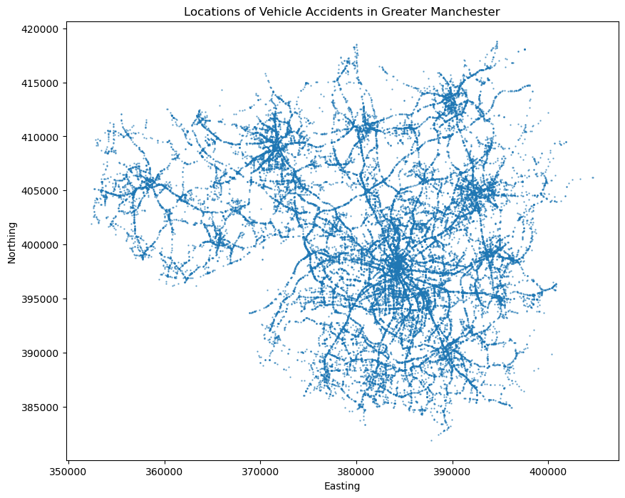

```python
# Basic scatter plot to visualize accident locations
plt.figure(figsize=(10, 8))  # Set the figure size
plt.scatter(accdata['Easting'], accdata['Northing'], s=0.5, alpha=0.6)
plt.title("Locations of Vehicle Accidents in Greater Manchester")
plt.xlabel("Easting")
plt.ylabel("Northing")
plt.show()
```

This plot gives a basic visualization of accident locations. The points form a rough outline of the road network in Greater Manchester. The next image adds a few flourishes to the picture by adding colours based on road class:

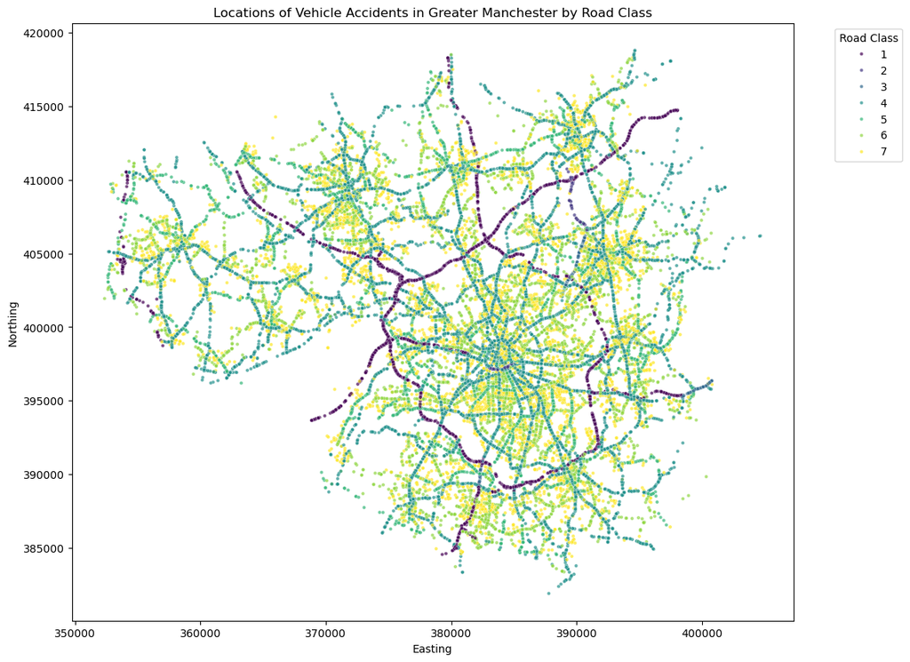

```python
# Scatter plot with colors for Road1Class
plt.figure(figsize=(12, 10))  # Adjust the figure size
sns.scatterplot(
    x='Easting',
    y='Northing',
    hue='Road1Class',  # Color points by Road1Class
    data=accdata,
    palette='viridis',  # Color palette
    s=10,  # Point size
    alpha=0.7  # Transparency
)
plt.title("Locations of Vehicle Accidents in Greater Manchester by Road Class")
plt.xlabel("Easting")
plt.ylabel("Northing")
plt.legend(title="Road Class", bbox_to_anchor=(1.05, 1), loc='upper left')  # Move legend outside
plt.show()
```

There are a number of important elements in these lines:

- The `sns.scatterplot()`creates a scatter plot where `x='Easting'` and `y='Northing'` are the coordinates.
- The `hue='Road1Class'` function colours the points based on `Road1Class`.
- The `data=accdata` function specifies the DataFrame as the source of data.
- The `palette='viridis'` uses a colour palette for better aesthetics.

At the same time we can also specify the customizing Legends. More specifically, the `bbox_to_anchor` and `loc` move the legend outside the plot for clarity.

This was only meant to get you a little excited about creating graphical representations of your work. Especially if you have previously worked with `ggplot` in R you may find [this walkthrough](https://datasquad.github.io/ECLR/Py_Graphing/Py_GraphIntro.html) to be a great introduction into creating graphs in Python.

## Summary

Before wrapping up your session in Jupyter Notebook, make sure to save your notebook file. That means that tomorrow you can just come back open the script file and continue to work. But before you do that recall what you learned here. You learned

- about the architecture of Jupyter notebooks
- how to import data into Python
- how to inspect objects that were created during your work
- how to create categorical variables and rename them
- how to create contingency tables
- that Python has powerful graphing tools

This walkthrough is part of the [ECLR](https://datasquad.github.io/ECLR/) page.